# CE/CNEE Predictions vs. UCSC mm39 35-way Conserved Elements

## Question

Our phastCons-derived CEs (`04-phastcons/regions`) and CNEEs (`05-cnees/phastcons/bed/*.cnees.bed4`) come from a 15-species Cactus alignment. As an independent sanity check, how well do they agree with UCSC’s `mm39-35way.bed` - conserved elements called from a completely different, much larger (35-species) multiz alignment, using a completely different pipeline (phastCons on multiz, not Cactus)? Agreement here isn’t proof of correctness, but strong disagreement would be a red flag; strong agreement is a meaningful, independent corroboration of what our pipeline is finding. This also compares our two `split_strategy` runs (`num_seqs`, now the default, and `ns`, from [[resource-usage-and-defaults.Rmd]]’s comparison) against this same external reference, and, separately, compares `cnees_from_conserved_chr`’s old CDS-subtract/fragment-split behavior against its new drop-entire-CE-on-any-CDS-overlap behavior (see “CNEE definition change” below) using two runs (`num_seqs`, `num_seqs_no_overlap`) that are identical in every other config setting.

## Methodology

Our reference (`GCA_000001635.9`) is the exact same assembly as UCSC’s mm39/GRCm39 - confirmed directly from the FASTA header (“GRCm39 reference primary assembly”), the reference GFF’s filename, and NCBI’s own `sequence_report.tsv` for this assembly. Same assembly means same coordinates - no liftover needed, only a chromosome-name translation (UCSC’s `chr1` etc. to GenBank accessions like `CM000994.3`), via `translate_ucsc_chroms.sh` in this directory (reusing the header-lookup `awk` idiom already used for exactly this in the support data repo’s `04_replace_bed_seqids_with_genbank.sh`), restricted to the 21 real chromosomes this pipeline actually has predictions for.

Per chromosome, per run (`num_seqs`, `ns`, `num_seqs_no_overlap`), per our-track (CE, CNEE), `compare_to_ucsc.py` runs `bedtools jaccard` and `bedtools intersect` (via `bedtools-env`’s `bedtools`, called by absolute path rather than `conda activate` - this session hit a real bug twice where `conda activate` doesn’t reliably win on `$PATH`) between our bed and the translated UCSC bed for that chromosome, producing `ucsc-comparison-flat.tsv`.

**A real pipeline quirk surfaced and worked around while building this**: the raw CE bed (`04-phastcons/regions`) uses phastCons’s own truncated chromosome name (e.g. `CM000994`, no version suffix) rather than the full accession every other output uses - the same thing `cnees_from_conserved_chr` already has to normalize internally when reading this same file to build CNEEs. `compare_to_ucsc.py` does the same normalization before comparing. Relatedly, the on-disk `04-phastcons/regions/{group}/{chrom}.bed` *file* sits next to a same-named `{chrom}/` *directory* (holding `run_phastcons_chr`’s small `chunks.done`/`global_rho.txt` bookkeeping files, left behind after `cleanup_chunk_intermediates` removes the real per-chunk outputs) - not a bug, but an easy thing to overlook browsing the output tree.

For the CNEE track specifically, UCSC’s track has no CDS subtracted while ours does, so the raw comparison undersells the real agreement. `compare_to_ucsc.py` also computes a fairer variant (`cnee_vs_nocds_ucsc`): `bedtools subtract`-ing our own per-chromosome CDS bed (`05-cnees/phastcons/bed/*.cds.bed`, already produced by `extract_cds_bed_chr` from the same reference GFF - no new CDS extraction needed) from the UCSC bed before comparing.

Separately, `compare_to_atac.py` checks how often each track (our CE/CNEE, all three runs, and UCSC’s raw CE) overlaps an independent ATAC-seq peak set - skin, late anagen (`GSM4156597_skin.late.anagen.peaks.mm39.bed`, translated the same way), producing `atac-comparison-flat.tsv`.

- **Data source**: `data/hamsters/workflow-tests/test-full-split-aln/` (`num_seqs`) and `data/hamsters/workflow-tests/test-full-gc/` (`ns`), the same two real, full 21-chromosome runs already compared to each other in `resource-usage-and-defaults.Rmd`; plus `data/hamsters/workflow-tests/test-no-overlap/` (`num_seqs_no_overlap`) - a third real, full 21-chromosome run with the exact same config as `num_seqs` (`split_strategy: num_seqs`, `rho_mode: fixed`, `fixed_rho: 0.3`, `cnee_ces_merge_gap_bp: 5`, `cnee_min_len_bp: 50` - confirmed identical from each run’s own `summary_report.html`) except that it was run after `cnees_from_conserved_chr`’s CDS-overlap handling changed from subtract-and-keep-fragments to drop-the-whole-CE, isolating the effect of that one algorithm change.
- **UCSC track**: `mm39-35way.bed` (`/n/holylfs05/LABS/informatics/Everyone/support/20251114-raftrey-hamster-wga/data/bed/`), 4,829,248 elements genome-wide; 4,826,807 fall within our 21 target chromosomes after translation.
- 189 rows (21 chromosomes x 3 runs x 3 tracks - `ce`, `cnee`, `cnee_vs_nocds_ucsc`) in `ucsc-comparison-flat.tsv`; 147 rows (21 chromosomes x 7 sources - 3 runs x 2 tracks plus `ucsc_ce`) in `atac-comparison-flat.tsv`.

## Overlap: CE and CNEE vs. UCSC, num_seqs vs. ns

This section is scoped to the two `split_strategy` runs (`num_seqs`, `ns`) only - `num_seqs_no_overlap` (same `split_strategy`, different CDS-overlap handling) is compared separately in “CNEE definition change” below, to keep the two independent axes of comparison from being conflated in the same plot.

Aggregate overlap vs. UCSC mm39 35-way, summed across all 21 chromosomes

| our_run | our_track | n_chroms | total_bp_ours | total_bp_ucsc | total_bp_intersect | mean_jaccard | pct_ours_in_ucsc | pct_ucsc_in_ours |
| --- | --- | --- | --- | --- | --- | --- | --- | --- |
| ns | ce | 21 | 140939708 | 150673314 | 78625691 | 0.356 | 55.8 | 52.2 |
| num_seqs | ce | 21 | 139193307 | 150673314 | 79473312 | 0.364 | 57.1 | 52.7 |
| ns | cnee | 21 | 86119768 | 150673314 | 48841475 | 0.250 | 56.7 | 32.4 |
| num_seqs | cnee | 21 | 91245906 | 150673314 | 51418308 | 0.259 | 56.4 | 34.1 |

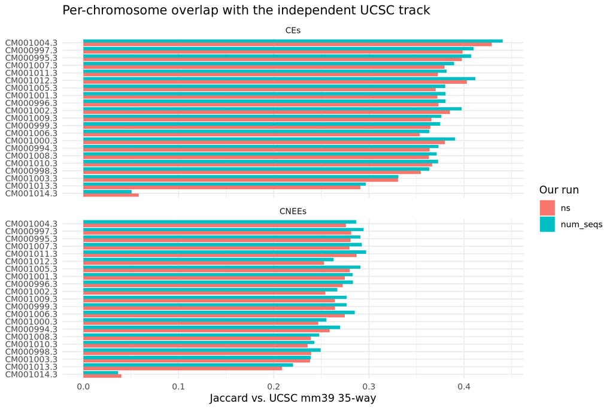

Both our CE and CNEE sets overlap the independent UCSC track substantially above zero across every chromosome, and the pattern is consistent with what’s already known about this alignment: `CM001014.3` (the poorly cross-species-aligned xy scaffold flagged earlier this session) shows dramatically lower agreement (Jaccard ~0.04-0.06) than every other chromosome (~0.2-0.44) - the independent UCSC track corroborates that this specific chromosome’s alignment quality problem is real, not an artifact of our own pipeline.

CE overlap is consistently a bit higher than CNEE overlap for both runs - expected, since UCSC’s track (like our raw CEs) includes coding regions, while our CNEEs have already had CDS subtracted out. The next section quantifies exactly how much of that gap is just the CDS-inclusion difference versus a real disagreement.

## A fairer CNEE comparison: subtracting CDS from UCSC’s track too

This section includes all three runs (`num_seqs`, `ns`, `num_seqs_no_overlap`) - unlike “Overlap” and “Scale” above, it isn’t scoped to the split-strategy comparison.

CNEEs vs. UCSC’s raw track vs. UCSC with our own CDS bed subtracted first

| our_run | our_track | mean_jaccard | pct_ours_in_ucsc | pct_ucsc_in_ours |
| --- | --- | --- | --- | --- |
| ns | cnee | 0.250 | 56.7 | 32.4 |
| ns | cnee_vs_nocds_ucsc | 0.291 | 56.7 | 39.3 |
| num_seqs | cnee | 0.259 | 56.4 | 34.1 |
| num_seqs | cnee_vs_nocds_ucsc | 0.302 | 56.4 | 41.4 |
| num_seqs_no_overlap | cnee | 0.247 | 56.0 | 32.2 |
| num_seqs_no_overlap | cnee_vs_nocds_ucsc | 0.287 | 56.0 | 39.0 |

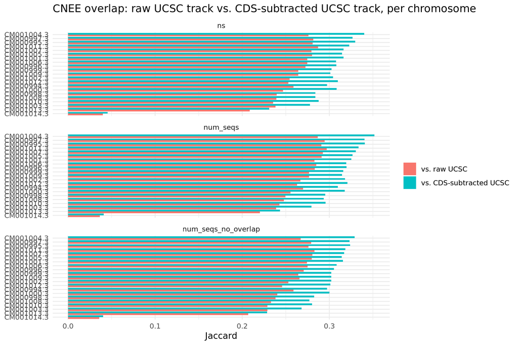

Subtracting CDS from UCSC’s track before comparing raises agreement for all three runs (mean Jaccard: `num_seqs` 0.259 -> 0.302, `ns` 0.250 -> 0.291, `num_seqs_no_overlap` 0.247 -> 0.287) - confirming the CE/CNEE gap above is partly, not entirely, a CDS-inclusion artifact rather than a real difference in what the two pipelines find non-coding-conserved. `num_seqs_no_overlap`’s gap (0.040) is only marginally smaller than `num_seqs`’s (0.042), even though its CNEEs never have CDS in them at all under the new definition - most of the remaining gap is better explained by scale (UCSC calling more, shorter elements; see “Scale” below) than by CDS-inclusion, under either CNEE definition.

## num_seqs vs. ns: which agrees more with the independent track?

num_seqs vs. ns agreement with UCSC, per chromosome (positive jaccard_diff = num_seqs agrees more)

| our_track | chrom | jaccard_num_seqs | jaccard_ns | pct_ours_in_ucsc_num_seqs | pct_ours_in_ucsc_ns | pct_ucsc_in_ours_num_seqs | pct_ucsc_in_ours_ns | jaccard_diff |
| --- | --- | --- | --- | --- | --- | --- | --- | --- |
| ce | CM000994.3 | 0.3731640 | 0.3636400 | 56.66 | 54.91 | 52.23 | 51.85 | 0.0095 |
| ce | CM000995.3 | 0.4073650 | 0.3975810 | 59.26 | 57.86 | 56.58 | 55.96 | 0.0098 |
| ce | CM000996.3 | 0.3805160 | 0.3729630 | 62.34 | 61.02 | 49.41 | 48.96 | 0.0076 |
| ce | CM000997.3 | 0.4098030 | 0.3984280 | 63.58 | 62.34 | 53.55 | 52.47 | 0.0114 |
| ce | CM000998.3 | 0.3635160 | 0.3544220 | 51.14 | 49.81 | 55.70 | 55.13 | 0.0091 |
| ce | CM000999.3 | 0.3750260 | 0.3644530 | 58.10 | 56.51 | 51.40 | 50.65 | 0.0106 |
| ce | CM001000.3 | 0.3904800 | 0.3798260 | 53.32 | 52.21 | 59.33 | 58.23 | 0.0107 |
| ce | CM001001.3 | 0.3803900 | 0.3718980 | 53.32 | 52.01 | 57.03 | 56.62 | 0.0085 |
| ce | CM001002.3 | 0.3973990 | 0.3848540 | 57.33 | 55.64 | 56.43 | 55.52 | 0.0125 |
| ce | CM001003.3 | 0.3308400 | 0.3304980 | 45.80 | 45.11 | 54.37 | 55.27 | 0.0003 |
| ce | CM001004.3 | 0.4405910 | 0.4288850 | 62.09 | 60.54 | 60.27 | 59.53 | 0.0117 |
| ce | CM001005.3 | 0.3800760 | 0.3701580 | 59.19 | 57.73 | 51.50 | 50.77 | 0.0099 |
| ce | CM001006.3 | 0.3634640 | 0.3531590 | 54.73 | 52.89 | 51.97 | 51.52 | 0.0103 |
| ce | CM001007.3 | 0.3895430 | 0.3794730 | 63.09 | 61.72 | 50.45 | 49.62 | 0.0101 |
| ce | CM001008.3 | 0.3711110 | 0.3631240 | 53.21 | 51.91 | 55.09 | 54.72 | 0.0080 |
| ce | CM001009.3 | 0.3761040 | 0.3658040 | 58.44 | 56.75 | 51.34 | 50.72 | 0.0103 |
| ce | CM001010.3 | 0.3726880 | 0.3664300 | 53.52 | 52.33 | 55.10 | 55.00 | 0.0063 |
| ce | CM001011.3 | 0.3816720 | 0.3724830 | 56.16 | 54.68 | 54.36 | 53.88 | 0.0092 |
| ce | CM001012.3 | 0.4116760 | 0.4029240 | 63.41 | 61.94 | 53.99 | 53.55 | 0.0088 |
| ce | CM001013.3 | 0.2965190 | 0.2909990 | 68.62 | 68.57 | 34.30 | 33.58 | 0.0055 |
| ce | CM001014.3 | 0.0505937 | 0.0582622 | 15.04 | 23.24 | 7.08 | 7.21 | -0.0077 |
| cnee | CM000994.3 | 0.2697600 | 0.2587350 | 56.33 | 56.30 | 34.11 | 32.38 | 0.0110 |
| cnee | CM000995.3 | 0.2909920 | 0.2808490 | 57.75 | 58.30 | 36.97 | 35.14 | 0.0101 |
| cnee | CM000996.3 | 0.2833550 | 0.2725220 | 61.07 | 61.88 | 34.58 | 32.75 | 0.0108 |
| cnee | CM000997.3 | 0.2945810 | 0.2815680 | 61.21 | 62.30 | 36.22 | 33.94 | 0.0130 |
| cnee | CM000998.3 | 0.2493900 | 0.2394250 | 50.42 | 50.06 | 33.04 | 31.46 | 0.0100 |
| cnee | CM000999.3 | 0.2766470 | 0.2642260 | 56.63 | 57.02 | 35.10 | 33.00 | 0.0124 |
| cnee | CM001000.3 | 0.2555050 | 0.2466670 | 50.98 | 51.56 | 33.87 | 32.11 | 0.0088 |
| cnee | CM001001.3 | 0.2829670 | 0.2746770 | 52.91 | 53.35 | 37.82 | 36.15 | 0.0083 |
| cnee | CM001002.3 | 0.2668980 | 0.2543820 | 53.94 | 54.23 | 34.57 | 32.39 | 0.0125 |
| cnee | CM001003.3 | 0.2389740 | 0.2382800 | 53.46 | 51.41 | 30.17 | 30.75 | 0.0007 |
| cnee | CM001004.3 | 0.2867640 | 0.2760020 | 57.58 | 58.21 | 36.36 | 34.42 | 0.0108 |
| cnee | CM001005.3 | 0.2911040 | 0.2800020 | 58.52 | 59.05 | 36.68 | 34.75 | 0.0111 |
| cnee | CM001006.3 | 0.2850520 | 0.2745470 | 55.94 | 55.65 | 36.76 | 35.15 | 0.0105 |
| cnee | CM001007.3 | 0.2926090 | 0.2795090 | 61.99 | 62.79 | 35.66 | 33.50 | 0.0131 |
| cnee | CM001008.3 | 0.2477460 | 0.2391020 | 50.94 | 51.10 | 32.54 | 31.00 | 0.0086 |
| cnee | CM001009.3 | 0.2766560 | 0.2642850 | 56.98 | 57.16 | 34.97 | 32.96 | 0.0124 |
| cnee | CM001010.3 | 0.2425800 | 0.2355890 | 53.39 | 53.41 | 30.77 | 29.65 | 0.0070 |
| cnee | CM001011.3 | 0.2969620 | 0.2868760 | 57.39 | 57.37 | 38.10 | 36.46 | 0.0101 |
| cnee | CM001012.3 | 0.2628940 | 0.2528770 | 58.94 | 59.79 | 32.18 | 30.47 | 0.0100 |
| cnee | CM001013.3 | 0.2204250 | 0.2086010 | 64.62 | 66.86 | 25.07 | 23.27 | 0.0118 |
| cnee | CM001014.3 | 0.0363851 | 0.0399166 | 13.51 | 22.07 | 4.74 | 4.65 | -0.0035 |

## Scale: element counts and lengths

Element counts and mean length: ours (both strategies, both tracks) vs. UCSC

| our_run | our_track | total_n_ours | mean_len_ours_bp |
| --- | --- | --- | --- |
| ns | ce | 2127094 | 66.3 |
| ns | cnee | 575157 | 149.7 |
| num_seqs | ce | 1554862 | 89.5 |
| num_seqs | cnee | 592809 | 153.9 |
| - | ucsc (per-chrom total) | 4826807 | 31.2 |

UCSC’s 35-way track calls roughly 2-3x more elements than either of our runs on the same chromosomes, consistent with it being built from a much deeper (35 vs 15 species) alignment - more species generally means more statistical power to detect shorter/weaker conservation signals. This scale difference is the main reason absolute overlap percentages sit around 25-40% rather than higher: a majority of UCSC’s smaller/weaker elements simply aren’t things a shallower alignment could ever call in the first place, independent of any real disagreement.

## CNEE definition change: drop-on-overlap vs. subtract-and-split

`cnees_from_conserved_chr` used to turn a conserved element (CE) into one or more CNEE candidates by *subtracting* CDS from it - a CDS in the middle of a CE split it into two flanking fragments, and a CDS clipping just one end left the non-overlapping remainder. It now instead drops the **entire** CE if it overlaps a CDS at all, no matter how - fully contained, split in the middle, or clipped at one end - so only CEs with zero CDS overlap become CNEE candidates. `num_seqs` (old behavior) and `num_seqs_no_overlap` (new behavior) are otherwise identical runs (see Data source above), isolating this one change.

CE -> CNEE-candidate funnel totals (before cnee_min_len_bp), old vs. new CDS-overlap handling

| run | total_ces_raw | total_ces_merged | total_candidates | pct_of_merged |
| --- | --- | --- | --- | --- |
| num_seqs | 1554862 | 1529874 | 1576531 | 103.0 |
| num_seqs_no_overlap | 1554867 | 1529868 | 1287232 | 84.1 |

Final CNEE set (after the cnee_min_len_bp length filter), old vs. new CDS-overlap handling

| our_run | total_n | total_bp | mean_len_bp |
| --- | --- | --- | --- |
| num_seqs | 592809 | 91245906 | 153.9 |
| num_seqs_no_overlap | 564824 | 86480567 | 153.1 |

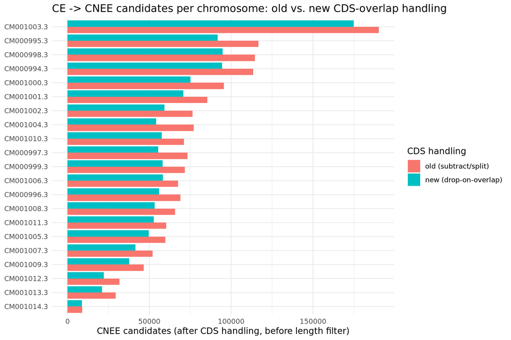

Genome-wide, the new definition keeps 18.4% fewer CNEE candidates (1,287,232 vs. 1,576,531) before the length filter, but only 6.7% less total bp (106.2 vs. 113.8 Mbp) - most of the count drop is fragments that only existed because the old behavior split one CE into two at every internal CDS, not new bp actually being excluded. The funnel table above makes this concrete: the old definition’s candidate count is 103.0% of the merged CE count - mathematically impossible under the new definition, which can only ever keep a CE whole or drop it, never turn one CE into more than one candidate. The new definition’s 84.1% is the first `cnee_after_cds_drop`-stage number that’s guaranteed to be <= 100% by construction. After the length filter, the gap narrows further (4.7% fewer elements, 5.2% less bp) since many of the short flanking fragments the old behavior produced wouldn’t have passed `cnee_min_len_bp` anyway. The new definition is stricter - every surviving CNEE is guaranteed to have zero CDS overlap at all, rather than “the non-coding part of a CE that touched a CDS somewhere” - at a modest cost in yield.

Does the new, stricter definition need less of a boost from CDS-subtracting UCSC’s track, since its CNEEs never have CDS in them to begin with? See “A fairer CNEE comparison” above, which covers all three runs together - the short answer is only marginally, since most of the remaining CE/CNEE-vs-UCSC gap is better explained by scale than by CDS-inclusion.

## Overlap with an independent ATAC-seq peak set

How often do CEs/CNEEs from either UCSC or our own pipeline land in independently accessible chromatin - skin, late anagen ATAC-seq peaks (`GSM4156597_skin.late.anagen`)?

ATAC-seq peak overlap by element count, Jaccard, and bp fraction - summed across all 21 chromosomes

| source | total_n_elements | total_n_overlapping | pct_elements_overlapping | mean_jaccard | pct_elements_bp_in_atac |
| --- | --- | --- | --- | --- | --- |
| ns_cnee | 575157 | 117759 | 20.47 | 0.0734 | 15.91 |
| num_seqs_cnee | 592809 | 121015 | 20.41 | 0.0742 | 15.55 |
| num_seqs_no_overlap_cnee | 564824 | 112810 | 19.97 | 0.0694 | 15.05 |
| ns_ce | 2127094 | 308182 | 14.49 | 0.0841 | 14.21 |
| num_seqs_ce | 1554862 | 252102 | 16.21 | 0.0834 | 14.16 |
| num_seqs_no_overlap_ce | 1554867 | 252100 | 16.21 | 0.0834 | 14.16 |
| ucsc_ce | 4826807 | 549865 | 11.39 | 0.0605 | 10.07 |

Three different ways of asking “how much overlap” tell a fuller story together, and don’t all agree on the same ranking. **By bp fraction** and **by element count**, our CNEEs (all three runs, ~15-16% of bp, ~20-20.5% of elements) lead raw CEs (~14.2%, ~14.5-16.2%), which lead UCSC’s raw track (~10.1%, ~11.4%) - CNEEs aren’t just bp-heavier where they overlap, more of them overlap at all. **Jaccard** breaks that ranking: raw CEs (~0.083-0.084) are actually higher than CNEEs (~0.069-0.074), both well above UCSC (~0.061). This isn’t a contradiction - Jaccard penalizes union size, and CEs (larger, includes coding regions) vs. CNEEs (smaller, non-coding only) trade off differently against a fixed-size ATAC peak set than bp-fraction or count-overlap do; the bp/count metrics answer “of what we predicted, how much lands in a peak”, while Jaccard also punishes predicting territory ATAC doesn’t touch. All three metrics agree that UCSC’s much larger, shorter-element track (see “Scale” above) ranks lowest on every measure.

`num_seqs_no_overlap`’s CNEEs (new, drop-on-overlap definition) overlap ATAC peaks at a slightly lower rate than `num_seqs`’s (old, subtract/split definition) on every metric - 19.97% vs. 20.41% of elements, 15.05% vs. 15.55% of bp, 0.069 vs. 0.074 Jaccard. The difference is small and the ranking among all sources is unchanged either way; it isn’t strong enough evidence on its own to say whether the CEs the new definition drops for CDS overlap were disproportionately near regulatory (ATAC-accessible) sequence, or whether this is just noise from a modestly smaller element set.

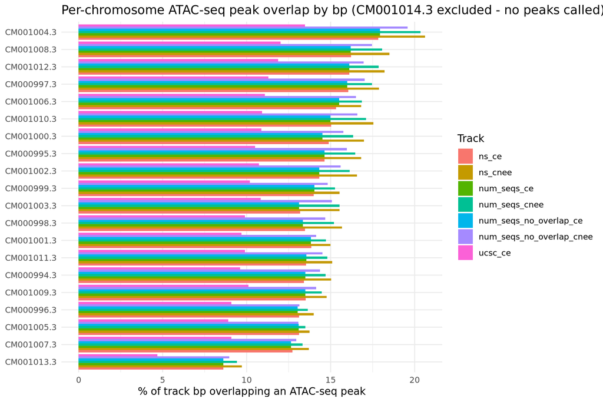

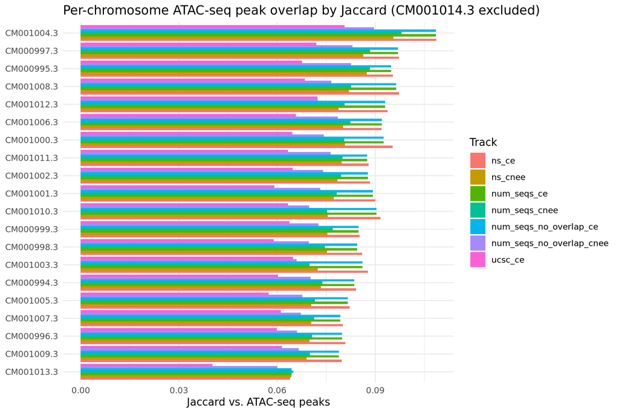

## Caveats

- **Not a ground truth.** UCSC’s 35-way track is itself a phastCons call on a different alignment, not an experimentally validated set of true conserved elements - agreement is corroborating evidence, not a correctness proof, and disagreement doesn’t necessarily mean either pipeline is wrong. The same applies to the ATAC-seq comparison in the other direction: it’s one tissue, one timepoint - absence of overlap there doesn’t mean an element isn’t real or isn’t regulatory in some other context.
- **`mm39-35way.bed`’s `score`/`lod` columns were not used for any filtering** - the full track is compared as-is. A confidence-filtered subset might show tighter agreement.
- **The phastCons chrom-name-truncation quirk** (see Methodology) affects only the raw CE bed; if any future consumer of `04-phastcons/regions/*.bed` reads it directly by chrom name without normalizing, it will silently fail the same way this analysis initially did.
- **`CM001014.3` has zero ATAC-seq peaks** in the source dataset entirely (not specific to our pipeline or UCSC) - excluded from the ATAC plot above for that reason, not because of any predicted-element issue.